# open access and alternative publishing

18 Oct 2021

## outline

- academic publishing: origins and some of the current mess
- open data and reproducibility

## introduction

## why should you care?

what’s in it for you?

- self-interest
- rules
- ethics

## academic publishing

## history

in the old days …

- printing and distribution were expensive
- journals and books were the only way to disseminate scientific information
- indexing was hard

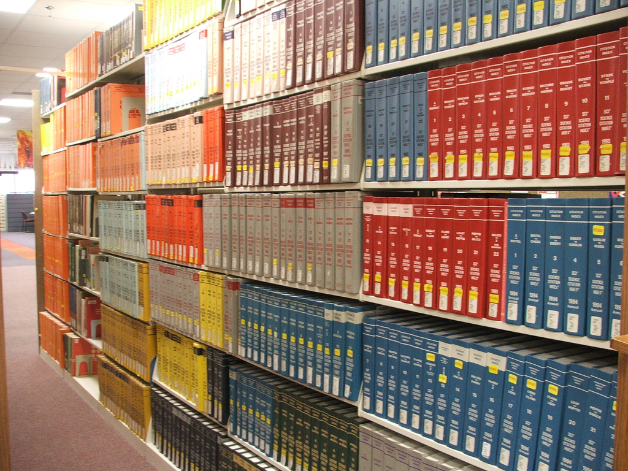

https://www.flickr.com/photos/7976207@N03/811269870

## scientific journals: why?

- peer-review (quality filter)
- editing (quality improvement)
- establish priority
- disseminate
- archive

## new kids on the block

internet enables distribution: alternatives to traditional model

- 1991: ArXiv
- 2000: [Faculty of 1000](https://en.wikipedia.org/wiki/Faculty_of_1000)
- 2003: [PLoS](https://en.wikipedia.org/wiki/PLOS)
- 2008: [ResearchGate](https://en.wikipedia.org/wiki/Researchgate)
- 2011: [figshare](https://en.wikipedia.org/wiki/Figshare)
- 2011: Scihub
- 2012: PeerJ
- 2013: [bioRxiv](https://en.wikipedia.org/wiki/BioRxiv)
- 2018: [ecoevorxiv](https://www.ecoevorxiv.com/about.html)
- 2019: [medRxiv](https://www.medrxiv.org)

## open access

- “green” open access: allow self-archiving
- “gold” open access: pay to make articles OA
  - many journals now allow gold option
- (and [other colours](https://en.wikipedia.org/wiki/Open_access) …)
- [tri-council rules](http://www.science.gc.ca/eic/site/063.nsf/eng/h_F6765465.html?OpenDocument):

> Grant recipients are required to ensure that any peer-reviewed journal publications arising from Agency-supported research are freely accessible within 12 months of publication.

## licensing

- what are your rights when you publish?
- what do you want to let people do?
- many ways to share
- [Creative Commons](https://creativecommons.org/)
  - e.g. CC BY, CC BY-SA, CC BY-NC, etc.

## journal classes

Open Access \(\neq\) not-for-profit

- not-for-profit (e.g. *Annual Reviews*)
- society (e.g. *Ecology*)
- commercial (e.g. Elsevier, Springer, Wiley, …)
- **predatory** OA: [Beall’s list](https://beallslist.net/)

## the [Ingelfinger rule](https://en.wikipedia.org/wiki/Ingelfinger_rule)

- journals won’t accept previously published material
- Bourne et al. (2017):

> very few journals consider preprints as a “prior form of publication” and reject such manuscripts on the grounds that they had been posted to a preprint server
- … but check [SHERPA/Romeo](http://www.sherpa.ac.uk/romeo/index.php) !

## citation advantage of OA (Tennant et al. 2016)

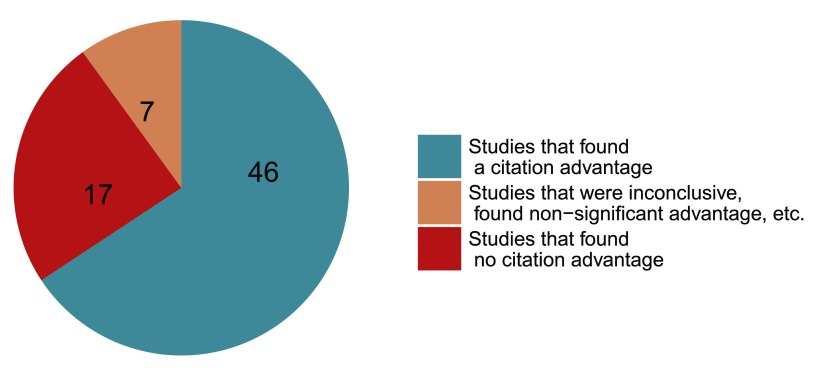

[OACA list](https://sparceurope.org/what-we-do/open-access/sparc-europe-open-access-resources/open-access-citation-advantage-service-oaca/oaca-list/)

## other ways to share

- academic social media: ResearchGate, Mendeley, academia.edu ?
  - what is the business model?
  - conditions of use? lock-in?
  - [“If you are not paying for it, you’re not the customer; you’re the product being sold”](https://www.metafilter.com/95152/Userdriven-discontent#32560467)
- social media
  - twitter, FB, blogging
  - be careful mixing academic and personal media …
  - do it well or don’t do it
- [altmetrics](https://www.altmetric.com/)

## peer review

**problems**: unremunerated, biased, …

experiments in peer review:

- double-blind
- open
- conversational/interactive
- crowdsourced ?
- [journal-independent](https://scholarlykitchen.sspnet.org/2017/03/20/wither-portable-peer-review/) (Peerage of Science, Rubriq)

## data

## why archive/share data?

- ethical obligation/good science
- re-use = visibility
- personal sanity: past-you and future-you

## data life history (Vines et al. 2014)

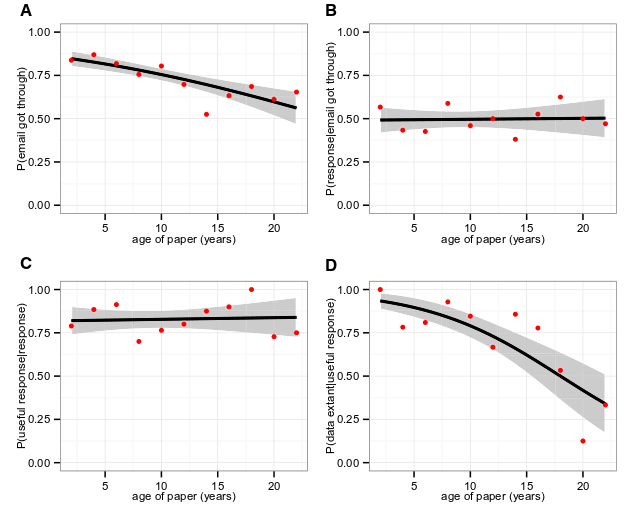

## data archiving in behavioural ecology

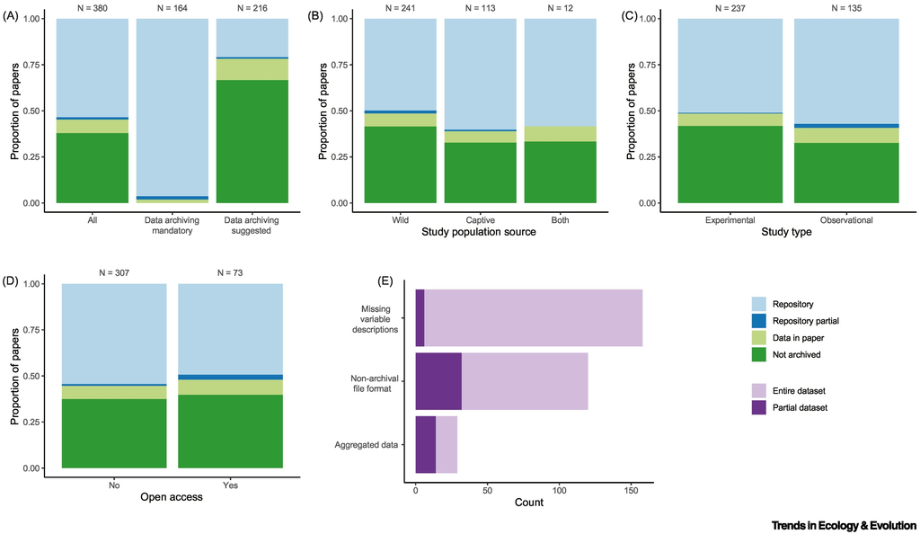

Miller et al. (2021) (see also Roche et al. (2015))

## [CIHR rules on data access](http://www.science.gc.ca/eic/site/063.nsf/eng/h_F6765465.html?OpenDocument)

> Deposit bioinformatics, atomic, and molecular coordinate data into the appropriate public database (e.g. gene sequences deposited in GenBank) immediately upon publication of research results …

> Retain original data sets for a minimum of five years after the end of the grant (or longer if other policies apply). This applies to all data, whether published or not.

## Should all data be open?

- human subjects: privacy issues
- commercial/IP issues
- “data parasites”

## data archiving

- Genbank etc.
- figshare
- Zenodo
- MacSphere
- DataDryad
- [list of repositories](http://oad.simmons.edu/oadwiki/Data_repositories)

## References

Bourne, PE et al. 2017.. *PLoS Computational Biology* 13 (5) (May). doi:10.1371/journal.pcbi.1005473. https://www.ncbi.nlm.nih.gov/pmc/articles/PMC5417409/.

Miller, SE et al. 2021.. *Trends in Ecology & Evolution* 36 (11) (November): 960–963. doi:10.1016/j.tree.2021.07.008. https://www.sciencedirect.com/science/article/pii/S0169534721002135.

Roche, DG et al. 2015.. *PLOS Biology* 13 (11) (November): e1002295. doi:10.1371/journal.pbio.1002295. https://journals.plos.org/plosbiology/article?id=10.1371/journal.pbio.1002295.

Tennant, JP et al. 2016.. *F1000Research* 5 (September). doi:10.12688/f1000research.8460.3. https://www.ncbi.nlm.nih.gov/pmc/articles/PMC4837983/.

Vines, TH et al. 2014.. *Current Biology* 24 (1) (January): 94–97. doi:10.1016/j.cub.2013.11.014. http://linkinghub.elsevier.com/retrieve/pii/S0960982213014000.